# Assessing Failure Modes

SSC 2026 ERGM Workshop · Module 4

## This Module’s Goal

From achieving convergence (Module 3) to diagnosing fit quality (this module):

- Produced a staged set of convergent ERGMs.
- But are the fitted models good enough?
- How do we diagnose the quality of model fit?

In this module, we will discuss:

- Practical considerations on the types of model failure.
- How we diagnose those failures.
- Some solutions to specific failure types.

## Our Fitting Sequence, Revisited

- Our “real pipeline” was similar to Module 3 (below)

| Step | Terms added | Fitting Algorithm |
| --- | --- | --- |
| 1–4 | `edges + nodemix(sex/young/race.num) + nodematch("chicago")` | MCMC (defaults) |
| 5 | `+ odegree(0)` | Stochastic Approximation (real pipeline) |
| 6 | `+ odegree(0:1)` | As above |
| 7 | `+ idegree(0:1) + odegree(0:1)` | Stochastic-Approximation + Hotelling |

- But, at the scale of our research problem, we needed to introduce Stochastic Approximation earlier.

## Some Ways in which ERGMs do not Fit

| What we saw | Symptom |
| --- | --- |
| **Degeneracy** | Simulated networks nearly empty or near-complete; `ergm` may error |
| **Non-convergence** | Chains don’t mix; `ergm` may error |
| **Poor alignment** | Converges, but simulated stats ≠ targets |

## Indicator #1

- In our **real pipeline** with standard tuning parameters, adding `odegree(0:2)` produced an error:

```
Error in ergm.MCMLE(...):
  Number of edges in a simulated network exceeds that in the
  observed by a factor of more than 20. This is a strong
  indicator of model degeneracy or a very poor starting
  parameter configuration.
```

- **Degeneracy:** the fitted model puts almost all its probability on a few **extreme graphs** (near-empty or near-complete).<sup>1</sup>
- Sometimes we see an error; other times the fitting process claims convergence, but the simulated networks are extreme.

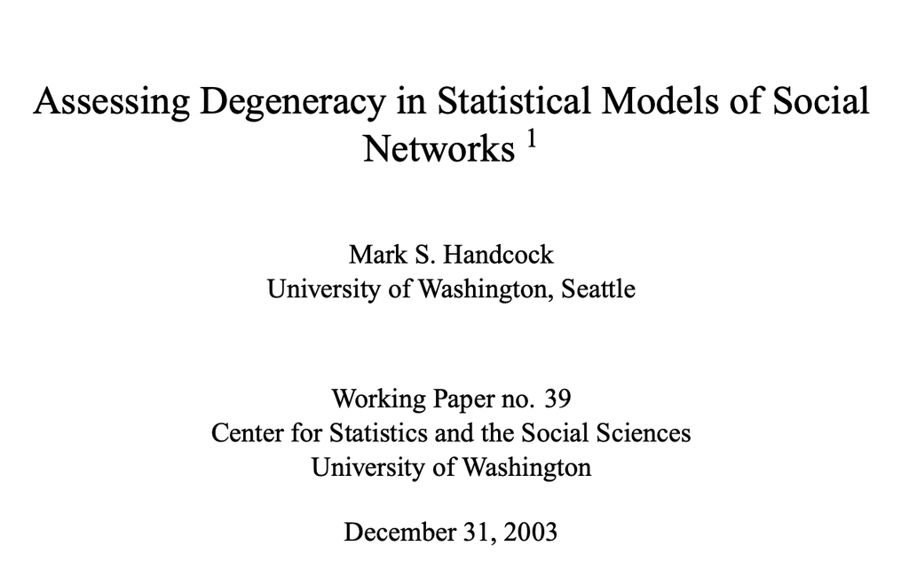

Handcock (2003)

[^1]: Handcock (2003), *Assessing Degeneracy in Statistical Models of Social Networks*, CSSS Working Paper 39. https://csss.uw.edu/files/working-papers/2003/wp39.pdf. Schweinberger (2011), *JASA* 106(496), 1361–1370.

## Indicator #1: Degeneracy Causes and Solutions

Cause:

```
1. Can be scale-dependent:
- E.g.,  `odegree(0:2)` fits  at n = 1,000 but not in the full research model.

2. Can be caused by parameters in the model
- E.g., Using `triangle` can create extreme positive feedback since a tie makes further ties more likely.
```

Degeneracy is a **model specification** problem.

- Usually cannot be fixed by control settings or warm-starting.
- Alternate parameteric specifications or scale investigations can help.

## Indicator #2

- A **non-convergence** failure (even when `ergm` may report **“converged”**).
- “Converged” means the algorithm *stopped*, not that the model sampled well.
- In such cases, the `mcmc.diagnostics(fitted_ergm_obj)` may still look poor.
- Example on next slide.

## Indicator #2 (Example)

A real MCMC diagnostic from our full pipeline

- The traces **drift upward/downward** (instead of settling around a stable mean)
- These plots show each statistic **relative to its target**, so the target is the **0 line**.
- Ideally, the density mass sits around 0 (not the case here).

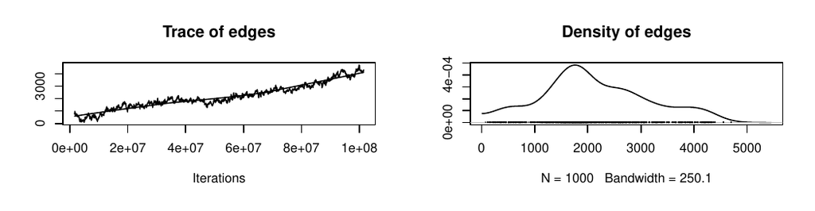

In this case:

- The model itself might be correctly specified.
- But, the control parameters might not be.
- The solution is often to **tune the controls** (Module 3).

## Indicator #3

- A fit converges cleanly (no degeneracy errors, MCMC diagnostics OK.)
- We still want to check if simulating from the fitted ERGM produces networks that match the targets.
- We **simulate many networks** (e.g., `sims <- simulate(fitted_ergm_obj, nsim=100)`).
- Compare distributions on all specified statistics relative to their **targets**.

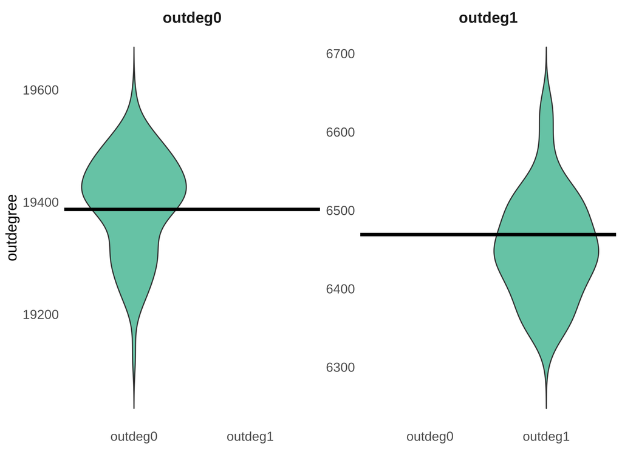

- This shows good alignment between the outdegree distribution on the simulated networks relative to the target (black line).

## Indicator #3 (continued)

But, there are three ways this can go:

1. MCMC diagnostics and simulated statistics both are good.
2. MCMC diagnostics: Borderline, Simulated structures <–> Targets align well.
3. MCMC diagnostics: Borderline, Simulated structures <–> Targets don’t align well.

Considerations:

1. Great! We are (almost) done!
2. We often care about the simulated network alignment with the targets. If upon repeating the simulation with different seeds, the simulated networks usually contain the targets, we are (arguably) done.
3. Further tune the ERGM controls (Module 3). If necessary, revisit data sources, computation of targets, and assess potential data quality/sampling considerations.

## Matching potential fixes to the failure modes

The fix depends on which failure we have:

| Failure | What it means | Fix |
| --- | --- | --- |
| **Degeneracy** | ERGM errors out, or simulated networks are (nearly) full or empty | Reparameterize the model (e.g., GWESP instead of triangles, as in Module 1) |
| **Non-convergence** | The MCMC diagnostics are poor | Tune the control parameters |
| **Poor alignment** | The fit converged | Revisit the specification, the target computation, or the data sampling/quality |

- Non-convergence (usually) indicates a *controls* problem.
- Degeneracy and poor alignment are either *model* or data quality/processing problems.

## Handoff to Module 5

We diagnosed these fits **by hand** – reading MCMC diagnostics and simulating a network to compare alignment.

Module 5: simulation as the *systematic* diagnostic (and the bridge to the ABM).